# Form-Deliverable1

David Dominguez - A01570975, Alejandra Suárez - A00835247, Daniel Nájera - A01709578, Eduardo Camacho - A01026437, Gabriel Medina - A01275763

2024-03-05

[figure not shown]

FORM BANNER

CD2001C – Analítica para Negocios: De Los Datos a las Decisiones Febrero – Junio 2024

# Entregable 1 – Evidencia 1

## Librerías Necesarias

```r
library(readr)
library(ggplot2)
library(tidyr)
library(viridis)
library(scales)
library(readxl)
library(RColorBrewer)
library(dplyr)
```

## 1. Explorar y Conocer la Empresa y su Contexto

### Antecedentes de la Empresa FORM

La empresa FORM, con sede en México, se ha destacado en el desarrollo de innovaciones en el empaque de autopartes, enfocándose en soluciones que permiten reducir el espacio necesario para almacenamiento y generando ahorros en logística. Han introducido un producto patentado globalmente que aumenta la capacidad de empaque y reduce significativamente el uso de materia prima, lo cual también tiene un impacto positivo en el medio ambiente.

Desde su fundación en 2011, FORM ha crecido significativamente, comenzando con un solo cliente y seis empleados, y expandiéndose a más de 150 colaboradores y atendiendo a más de 15 clientes automotrices. Entre sus clientes se encuentran nombres prominentes como Denso, Magna, International Automotive Components y Varroc Lighting Systems.

La especialización de FORM en empaques para autopartes delicadas y costosas la ha llevado a ser proveedor de armadoras de prestigio como Tesla, BMW y Mercedes Benz. Ofrecen soluciones personalizadas que aseguran la protección y la integridad de las autopartes durante su transporte, lo que es crucial para piezas de acabado delicado o espejo.

Con una planta en Apodaca, Nuevo León, la empresa ha establecido un área especializada para empaques termoformados, esenciales para el transporte de piezas electrónicas y otras autopartes sensibles que requieren cuidado especial para evitar daños durante el tránsito.

La filosofía de FORM de reducir el espacio de almacenamiento, la mano de obra para la administración y el armado de empaques, junto con la protección del producto, se alinea con la demanda creciente de la industria automotriz por eficiencia y sostenibilidad en las cadenas de suministro.

Las innovaciones de FORM y su enfoque en la sostenibilidad y eficiencia reflejan un compromiso con la mejora continua y la adaptación a las necesidades cambiantes del mercado automotriz, lo que les ha permitido mantenerse competitivos y relevantes en un sector en constante evolución.

#### Misión

Transformar nuestro entorno y resolver retos industriales de nuestros clientes a través de la colaboración, provocando nuevas oportunidades que potencian nuestro modelo de negocio, para alcanzar nuestros ideales.

#### Visión

En 2033 seremos una de las cinco mejores compañías de México que generan valor dentro de la cadena de suministro de las industrias que más valoran la forma en la que se protegen y trasladan las cosas.

#### Objetivo Estratégico

“Ahora estamos volteando a los Estados Unidos, y ahora con la posibilidad de que Tesla llegue a Nuevo León, con mayor sentido volteamos hacia allá. Si todos nuestros clientes son automotrices e internacionales por qué no proveerlos en Estados Unidos, estamos trabajando fuerte para lograrlo”. - Felipe Flores García

### Análisis de las áreas de la Empresa (incluir 3-5 gráficos usando R*)usando datos

```r
df= read_xlsx("/Users/daviddrums180/Tec/Case_Study_Form/databases/form/temporary/BDD_FORM_BAJAS_2023.xlsx")

df <- df %>% drop_na()
```

```r
summary(df)
```

```
##       No.         Apellidos            Nombre          Fecha de Nacimiento
##  Min.   :1.000   Length:54          Length:54          Min.   :24295
##  1st Qu.:1.000   Class :character   Class :character   1st Qu.:32382
##  Median :1.000   Mode  :character   Mode  :character   Median :35725
##  Mean   :1.056                                         Mean   :34441
##  3rd Qu.:1.000                                         3rd Qu.:37254
##  Max.   :3.000                                         Max.   :38250
##     Género              RFC            Fecha de Alta     Primer Mes
##  Length:54          Length:54          Min.   :44420   Min.   :44450
##  Class :character   Class :character   1st Qu.:44765   1st Qu.:44795
##  Mode  :character   Mode  :character   Median :44968   Median :44998
##                                        Mean   :44887   Mean   :44917
##                                        3rd Qu.:45072   3rd Qu.:45102
##                                        Max.   :45091   Max.   :45121
##    Cuarto Mes    Fecha de Baja   Motivo de Baja        Puesto
##  Min.   :44540   Min.   :44928   Length:54          Length:54
##  1st Qu.:44885   1st Qu.:45092   Class :character   Class :character
##  Median :45090   Median :45103   Mode  :character   Mode  :character
##  Mean   :45009   Mean   :45096
##  3rd Qu.:45194   3rd Qu.:45122
##  Max.   :45213   Max.   :45166
##      Dpto               Imss                SD
##  Length:54          Length:54          Length:54
##  Class :character   Class :character   Class :character
##  Mode  :character   Mode  :character   Mode  :character
##
##
##
##  Factor de Crédito Infonavit No. De Crédito Infonavit     CURP
##  Length:54                   Length:54                Length:54
##  Class :character            Class :character         Class :character
##  Mode  :character            Mode  :character         Mode  :character
##
##
##
##     Calle              Número            Colonia           Municipio
##  Length:54          Length:54          Length:54          Length:54
##  Class :character   Class :character   Class :character   Class :character
##  Mode  :character   Mode  :character   Mode  :character   Mode  :character
##
##
##
##     Estado                CP        Estado Civil       Número de Télefono
##  Length:54          Min.   :25900   Length:54          Min.   :8.320e+07
##  Class :character   1st Qu.:66646   Class :character   1st Qu.:8.122e+09
##  Mode  :character   Median :66646   Mode  :character   Median :8.131e+09
##                     Mean   :62956                      Mean   :7.883e+09
##                     3rd Qu.:66648                      3rd Qu.:8.139e+09
##                     Max.   :67267                      Max.   :9.841e+09
```

```r
df <- df %>%
  mutate(Dpto = if_else(Dpto == "Produccion Cartón MC", "Producción Cartón MC", Dpto))
```

#### Bajas por Departamento

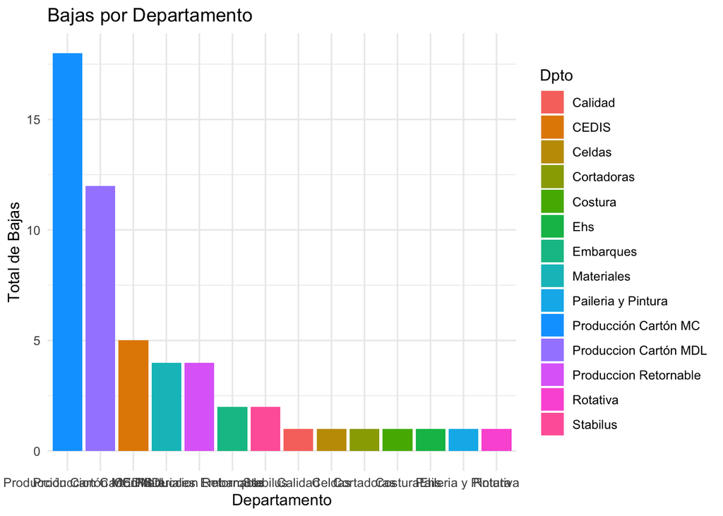

```r
bajas_por_departamento <- df %>%
  group_by(Dpto) %>%
  summarise(Total_Bajas = n())

ggplot(bajas_por_departamento, aes(x = reorder(Dpto, -Total_Bajas), y = Total_Bajas, fill = Dpto)) +
  geom_bar(stat = "identity") +
  theme_minimal() +
  labs(title = "Bajas por Departamento", x = "Departamento", y = "Total de Bajas")
```

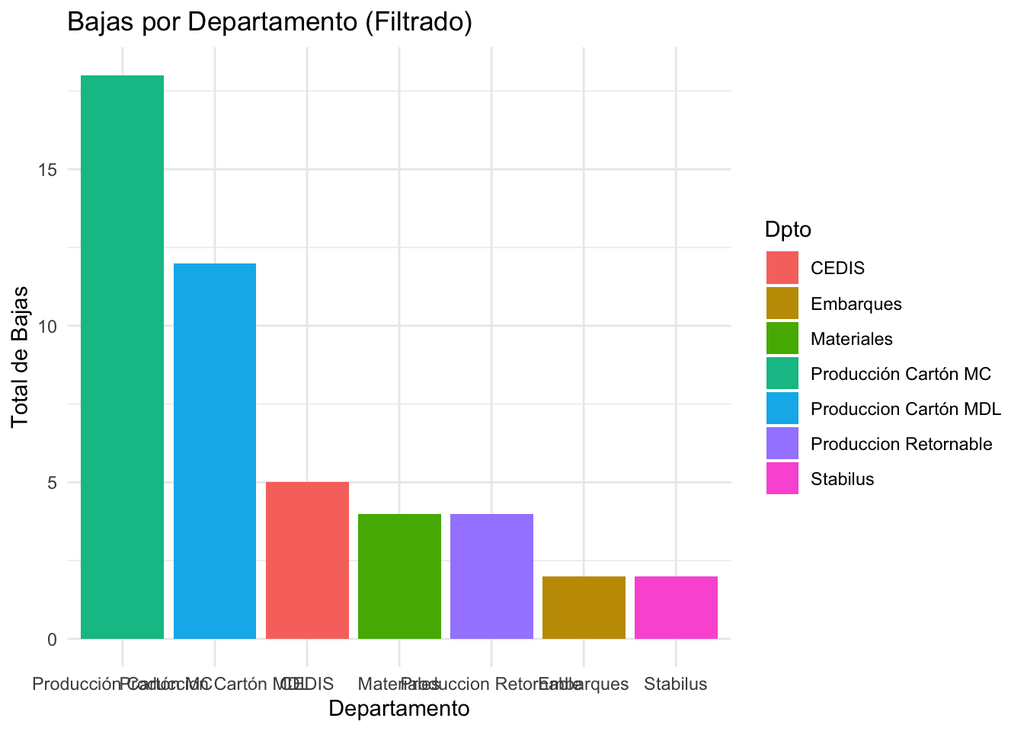

```r
bajas_por_departamento <- df %>%
  group_by(Dpto) %>%
  summarise(Total_Bajas = n()) %>%
  filter(Total_Bajas > 1)

# Ordenamos las bajas por departamento de mayor a menor en el gráfico
ggplot(bajas_por_departamento, aes(x = reorder(Dpto, -Total_Bajas), y = Total_Bajas, fill = Dpto)) +
  geom_bar(stat = "identity") +
  theme_minimal() +
  labs(title = "Bajas por Departamento (Filtrado)", x = "Departamento", y = "Total de Bajas")
```

#### Bajas por Departamento y Género

```r
bajas_por_departamento_genero <- df %>%
  group_by(Dpto, Género) %>%
  summarise(Total_Bajas = n())
```

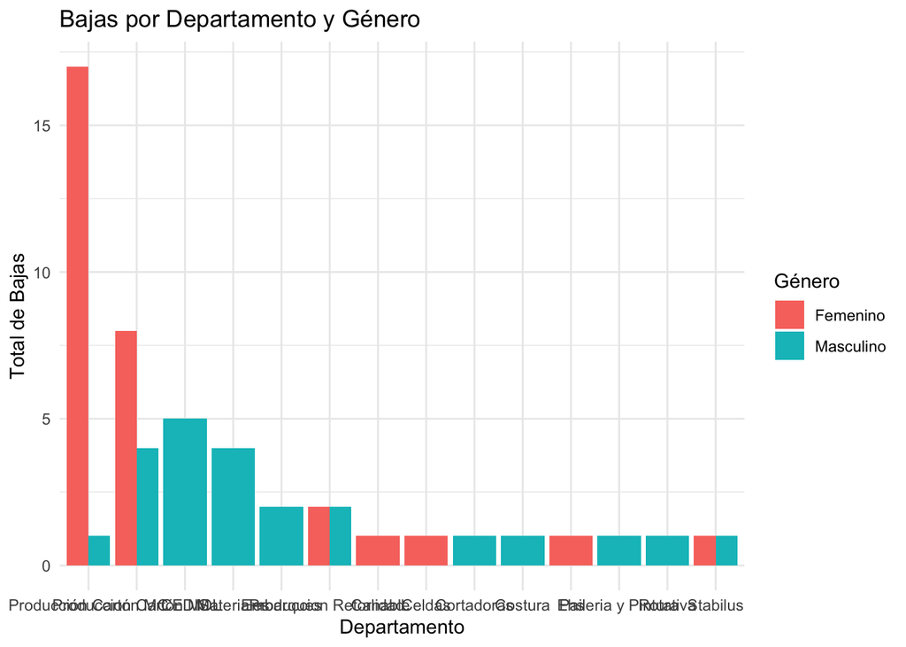

```r
ggplot(bajas_por_departamento_genero, aes(x = reorder(Dpto, -Total_Bajas), y = Total_Bajas, fill = Género)) +
  geom_bar(stat = "identity", position = "dodge") +
  theme_minimal() +
  labs(title = "Bajas por Departamento y Género", x = "Departamento", y = "Total de Bajas")
```

```r
bajas_por_departamento_genero <- df %>%
  group_by(Dpto, Género) %>%
  summarise(Total_Bajas = n()) %>%
  filter(Total_Bajas > 1)
```

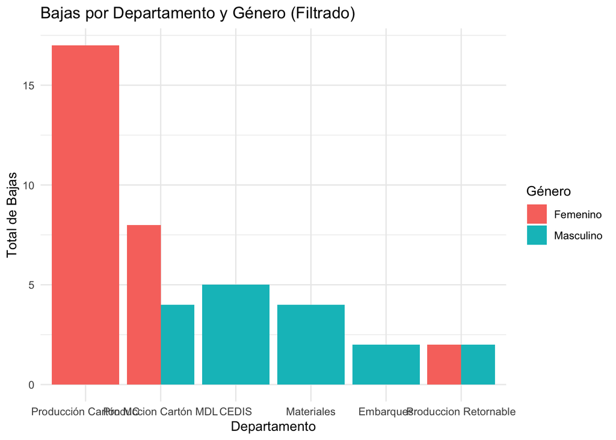

```r
ggplot(bajas_por_departamento_genero, aes(x = reorder(Dpto, -Total_Bajas), y = Total_Bajas, fill = Género)) +
  geom_bar(stat = "identity", position = "dodge") +
  theme_minimal() +
  labs(title = "Bajas por Departamento y Género (Filtrado)", x = "Departamento", y = "Total de Bajas")
```

#### Bajas por Motivo y Género

```r
bajas_por_motivo_genero <- df %>%
  group_by(`Motivo de Baja`, Género) %>%
  summarise(Total_Bajas = n())
```

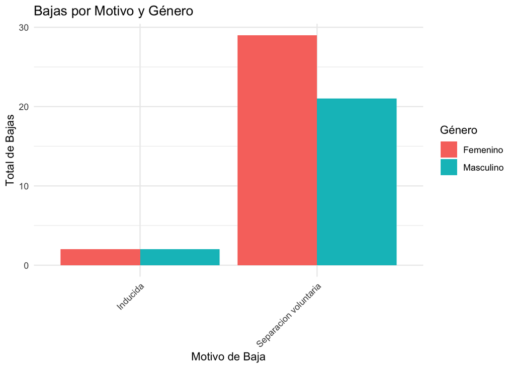

```r
ggplot(bajas_por_motivo_genero, aes(x = `Motivo de Baja`, y = Total_Bajas, fill = Género)) +
  geom_bar(stat = "identity", position = "dodge") +
  theme_minimal() +
  labs(title = "Bajas por Motivo y Género", x = "Motivo de Baja", y = "Total de Bajas") +
  theme(axis.text.x = element_text(angle = 45, hjust = 1))
```

Como podemos observar en estas gráficas, los dos departamentos donde vemos una mayor cantidad de bajas es en Producción de Cartón tanto MC como ML. Esto nos hace entender que ahí hay un problema grave y se tienen que tomar cartas en el asunto para detectarlo lo antes posible para generar alguna estrategia para abolirlo. De las 18 personas que fueron bajas de la empresa 17 fueron mujeres, algo que nos podría indicar un problema grave relacionado al tema de género.

```r
df$`Fecha de Baja` <- as.Date(df$`Fecha de Baja`, origin = "1899-12-30")

df$AñoMes <- format(df$`Fecha de Baja`, "%Y-%m")
```

#### Tendencia de Bajas a lo Largo del Tiempo

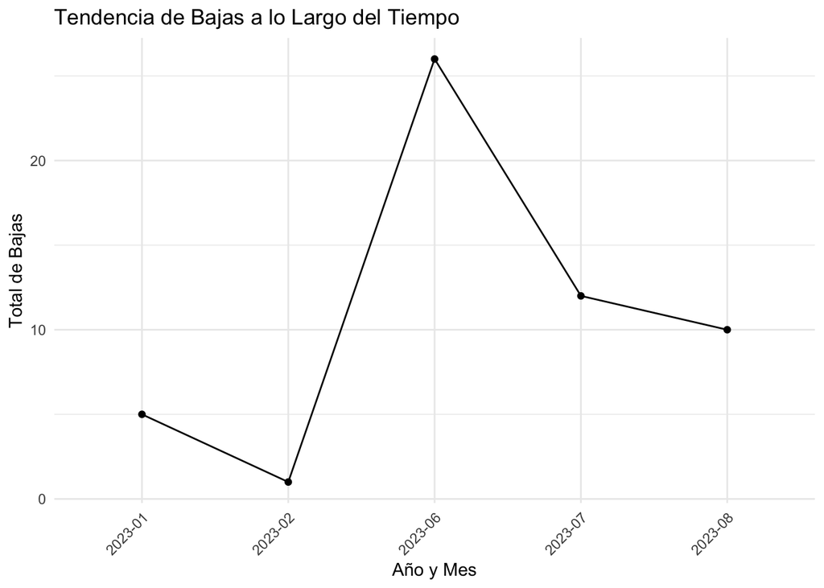

```r
bajas_por_fecha <- df %>%
  group_by(AñoMes) %>%
  summarise(Total_Bajas = n())

ggplot(bajas_por_fecha, aes(x = AñoMes, y = Total_Bajas, group = 1)) +
  geom_line() +
  geom_point() +
  theme_minimal() +
  labs(title = "Tendencia de Bajas a lo Largo del Tiempo", x = "Año y Mes", y = "Total de Bajas") +
  theme(axis.text.x = element_text(angle = 45, hjust = 1))
```

#### Bajas Totales por Mes

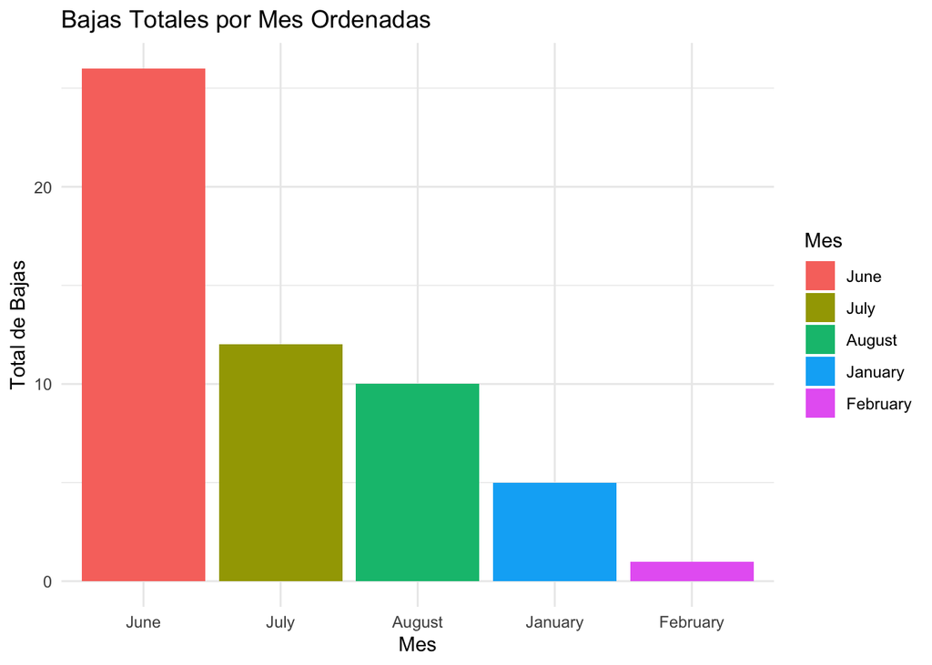

```r
df$`Fecha de Baja` <- as.Date(df$`Fecha de Baja`, origin = "1899-12-30")

bajas_por_mes <- df %>%
  mutate(Mes = format(`Fecha de Baja`, "%B")) %>%
  group_by(Mes) %>%
  summarise(Total_Bajas = n())

meses <- format(seq(as.Date("2000-01-01"), as.Date("2000-12-01"), by = "month"), "%B")
bajas_por_mes$Mes <- factor(bajas_por_mes$Mes, levels = meses)

# Ahora ordenamos los datos para el gráfico
bajas_por_mes <- bajas_por_mes %>%
  mutate(Mes = reorder(Mes, -Total_Bajas))

# Gráfico de barras mostrando las bajas totales por mes, ordenadas de mayor a menor
ggplot(bajas_por_mes, aes(x = Mes, y = Total_Bajas, fill = Mes)) +
  geom_bar(stat = "identity") +
  theme_minimal() +
  labs(title = "Bajas Totales por Mes Ordenadas", x = "Mes", y = "Total de Bajas")
```

A falta datos de Marzo a Mayo, podemos inferir que no hubieron bajas en la empresa, sin embargo vemos un gran incremento en las bajas en el mes de junio, lo que hace mucho sentido. Esto que se observa puede ser por una razón legal en cuanto a temas de cotratos o puede tener cierta relación con un problema que pudo haber dentro de la parte de producción de cartón, pues la mayoría de estas bajas en el mes fueron de igual manera por esta razón. Se debe de realizar un análisis a mayor profundidad para entender de una mejor forma.

#### Bajas por Estado Civil

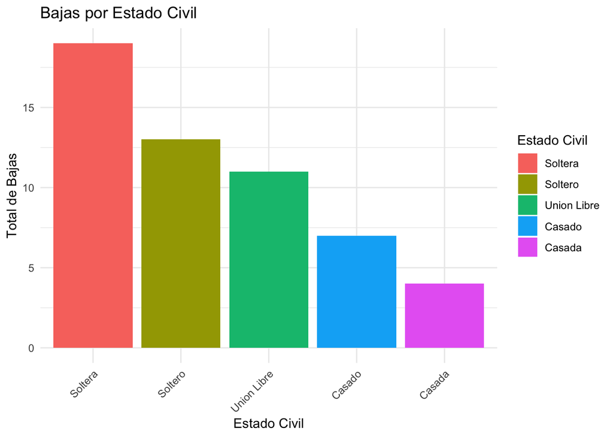

```r
bajas_por_estado_civil <- df %>%
  group_by(`Estado Civil`) %>%
  summarise(Total_Bajas = n()) %>%
  mutate(`Estado Civil` = reorder(`Estado Civil`, -Total_Bajas))

ggplot(bajas_por_estado_civil, aes(x = `Estado Civil`, y = Total_Bajas, fill = `Estado Civil`)) +
  geom_bar(stat = "identity") +
  theme_minimal() +
  labs(title = "Bajas por Estado Civil", x = "Estado Civil", y = "Total de Bajas") +
  theme(axis.text.x = element_text(angle = 45, hjust = 1))
```

#### Desempeño reciente

En cuanto al desempeño reciente de la empresa, podemos ver que es una empresa sólida, líder en el mercado mexicano para la producción de empaques de cartón y empaque retornable para autopartes y que busca internacionalizarse. Aunado a esto, se está generando una nueva oportunidad como lo es el nearshoring, que ya está sucediendo en la República Mexicana, que va a permitir a empresas como FORM tener un crecimiento exponencial, prestándoles sus servicios o sus productos a diferentes empresas, en este caso de automovilismo.

Sin embargo, podemos ver que la empresa se enfrenta a una alta rotación de sus empleados, lo que está provocando que sea mucho más ineficiente dentro de la producción de las cajas y al estar constantemente capacitando personal nuevo, lo que quita mucho tiempo para poder ser más eficiente dentro de las tareas, pues se tratan de tareas manuales y repetitivas que con el paso del tiempo hacen que las personas se vuelvan más eficientes haciendo esa tarea en específico, lo que ha llevado a FORM a querer entender de una mucho mejor manera a sus empleados

### Contexto de la Industria

#### Análisis de la Industria (cartón, autopartes, automotriz)

Para el caso de México y E.U.A. (incluir 3-5 gráficos usando R*) usando fuentes de datos secundarias

El mercado automotriz en México constituye un sector vital para la economía del país, no solo por su significativa contribución al Producto Interno Bruto (PIB) sino también por su papel en la creación de empleos y en el fomento de la innovación tecnológica. Una faceta crucial de esta industria es el mercado de autopartes, que se erige como un pilar fundamental para la operatividad y el desarrollo de la industria automotriz en su conjunto. Este segmento incluye desde la fabricación de componentes esenciales del vehículo hasta sistemas avanzados que mejoran la seguridad, el rendimiento y la comodidad.

La interacción entre los fabricantes de automóviles y los proveedores de autopartes es intrínseca al ciclo de vida del producto automotriz, afectando directamente la cadena de suministro, la innovación en el diseño de productos y, en última instancia, la competitividad en el mercado global. Además, el mercado de autopartes en México se ve influenciado por factores como las regulaciones gubernamentales, los tratados de libre comercio, las tendencias de consumo y los avances tecnológicos, lo que lo convierte en un campo de estudio dinámico y complejo.

#### Exploración de Exportación de Vehículos

Para profundizar en el entendimiento de esta industria, se realizará un análisis exhaustivo utilizando diversas bases de datos recopiladas de múltiples fuentes. Este análisis buscará identificar tendencias, desafíos y oportunidades dentro del mercado de autopartes, así como su interconexión con la industria automotriz en general. Se examinarán aspectos como la evolución de la demanda de autopartes, la cadena de valor, el impacto de la tecnología en la producción y el diseño de autopartes, así como las estrategias adoptadas por las empresas para navegar en un entorno económico y regulatorio en constante cambio.

**Analisis de Exportación de Vehiculos**

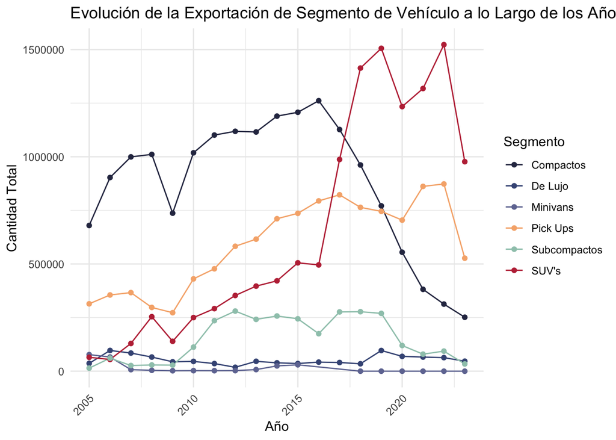

```r
mx_vehicle_exports <- read_excel("/Users/daviddrums180/Tec/Case_Study_Form/databases/industry_autos_mx/exportacion_vehiculos.xlsx")

mx_vehicle_exports_summary <- mx_vehicle_exports %>%
  group_by(Año, Segmento) %>%
  summarise(Cantidad_Total = sum(Cantidad, na.rm = TRUE))

# Definir la paleta de colores personalizada
colores <- c("#2D3250", "#435585", "#7077A1", "#F6B17A", "#9EC8B9", "#BE3144")

# Asegurarse de que hay suficientes colores para los segmentos
# Repetir la paleta si hay más segmentos que colores
n_segmentos <- length(unique(mx_vehicle_exports_summary$Segmento))
if (n_segmentos > length(colores)) {
  colores <- rep(colores, length.out = n_segmentos)
}

# Gráfico de líneas con la paleta de colores personalizada
ggplot(mx_vehicle_exports_summary, aes(x = Año, y = Cantidad_Total, color = Segmento, group = Segmento)) +
  geom_line() + # Dibuja líneas
  geom_point() + # Añade puntos en cada dato
  scale_color_manual(values = colores) + # Usa la paleta de colores definida
  theme_minimal() + # Usa un tema minimalista
  labs(title = "Evolución de la Exportación de Segmento de Vehículo a lo Largo de los Años",
       x = "Año",
       y = "Cantidad Total") +
  theme(axis.text.x = element_text(angle = 45, hjust = 1))
```

**4. Beneficios Potenciales para FORM:** - El análisis de estas tendencias es vital para FORM, ya que proporciona información sobre qué segmentos podrían requerir más empaques en el futuro. Esto puede guiar sus decisiones de inversión y estrategias de producción para los próximos años.

**5. Modelo Predictivo para la Demanda:** - Utilizar estos datos para desarrollar un modelo predictivo podría ayudar a FORM a anticiparse a las necesidades del mercado. Herramientas de análisis predictivo, como el Machine Learning, podrían usarse para prever la demanda futura basándose en las tendencias históricas y factores externos.

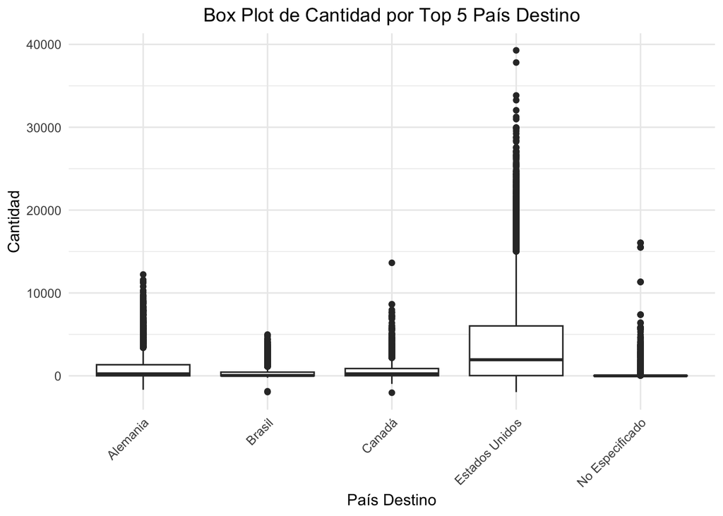

```r
# Sumarizar la cantidad total por País destino y obtener los top 5
top_paises_destino <- mx_vehicle_exports %>%
  group_by(`País destino`) %>%
  summarise(Cantidad_Total = sum(Cantidad, na.rm = TRUE)) %>%
  arrange(desc(Cantidad_Total)) %>%
  slice_head(n = 5)

# Filtrar el dataframe original para tener solo los top 5 País destino
mx_vehicle_exports_top5 <- mx_vehicle_exports %>%
  filter(`País destino` %in% top_paises_destino$`País destino`)

# Código para un box plot de la variable Cantidad por los top 5 País destino
ggplot(mx_vehicle_exports_top5, aes(x = `País destino`, y = Cantidad)) +
  geom_boxplot() +
  theme_minimal() +
  labs(title = "Box Plot de Cantidad por Top 5 País Destino",
       x = "País Destino",
       y = "Cantidad") +
  theme(axis.text.x = element_text(angle = 45, hjust = 1),
        plot.title = element_text(hjust = 0.5))
```

**1. Dominancia de Estados Unidos:** - Estados Unidos muestra una mediana y un rango intercuartílico superior a otros destinos, lo cual indica que es el principal mercado para la exportación. FORM puede centrarse en aumentar la capacidad de producción y mejorar las soluciones logísticas para satisfacer la alta demanda de empaques en este mercado.

**3. Consistencia en Alemania y Brasil:** - Alemania y Brasil muestran una menor dispersión y consistencia en los envíos, lo que podría reflejar mercados establecidos con demandas predecibles. FORM puede utilizar esta información para optimizar inventarios y prever recursos de producción.

**4. Beneficios del Análisis para FORM:** - Analizar esta distribución de exportaciones podría ayudar a FORM a entender mejor la variabilidad y la consistencia en la demanda entre diferentes mercados. Esta información puede ser crítica para optimizar la cadena de suministro y poder desarrollar un modelo que ayude a predecir y controlar los niveles de inventario necesarios.

**5. Modelo Predictivo para la Demanda:** - Desarrollar un modelo predictivo basado en estos datos permitiría a FORM anticipar la demanda y ajustar la producción de forma proactiva. La utilización de técnicas estadísticas como la regresión, conjuntamente con algoritmos de machine learning, podría proporcionar estimaciones precisas de la demanda futura basándose en patrones históricos y tendencias actuales.

#### Exploración a Mercado de Autopartes

A través de este enfoque analítico, se espera obtener insights valiosos que contribuyan a una mejor comprensión del mercado de autopartes en México y su rol crítico dentro de la industria automotriz. Estos hallazgos podrían ofrecer directrices para la toma de decisiones estratégicas por parte de los actores de la industria, así como para el diseño de políticas públicas que promuevan el crecimiento y la sostenibilidad del sector. La metodología y los resultados de este análisis estarán fundamentados en la información detallada proporcionada en las bases de datos, cuyas fuentes se encuentran meticulosamente documentadas en el README adjunto a las bases de datos, asegurando así la transparencia y la fiabilidad de la investigación realizada.

**Importaciónes, Exportaciónes y Producción de Autopartes**

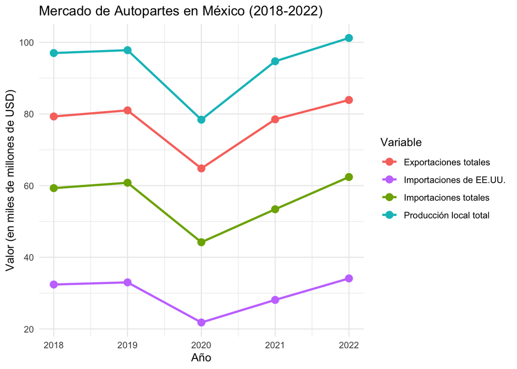

```r
mx_autoparts_market <- read_csv("/Users/daviddrums180/Tec/Case_Study_Form/databases/industry_autos_mx/mx_autoparts_market.csv")

# Colores
colors <- c("Producción local total" = "#00BFC4",
            "Exportaciones totales" = "#F8766D",
            "Importaciones totales" = "#7CAE00",
            "Importaciones de EE.UU." = "#C77CFF")


# Usar ggplot2 para graficar directamente los datos
ggplot(data = mx_autoparts_market) +
  geom_line(aes(x = year, y = total_local_production, group = 1, colour = "Producción local total"), size = 1) +
  geom_line(aes(x = year, y = total_exports, group = 1, colour = "Exportaciones totales"), size = 1) +
  geom_line(aes(x = year, y = total_imports, group = 1, colour = "Importaciones totales"), size = 1) +
  geom_line(aes(x = year, y = imports_from_US, group = 1, colour = "Importaciones de EE.UU."), size = 1) +
  geom_point(aes(x = year, y = total_local_production, colour = "Producción local total"), size = 3) +
  geom_point(aes(x = year, y = total_exports, colour = "Exportaciones totales"), size = 3) +
  geom_point(aes(x = year, y = total_imports, colour = "Importaciones totales"), size = 3) +
  geom_point(aes(x = year, y = imports_from_US, colour = "Importaciones de EE.UU."), size = 3) +
  scale_colour_manual(values = colors) +
  labs(title = "Mercado de Autopartes en México (2018-2022)",
       x = "Año",
       y = "Valor (en miles de millones de USD)",
       colour = "Variable") +
  theme_minimal()
```

**2. Exportaciones Totales:** - Las exportaciones muestran una reducción significativa en 2020, posiblemente debido al impacto de la pandemia de COVID-19 en el comercio global. - Se observa una recuperación fuerte en 2021 y 2022, indicando una posible resiliencia o adaptación del mercado de exportación.

**Mercado de Autopartes Mx**

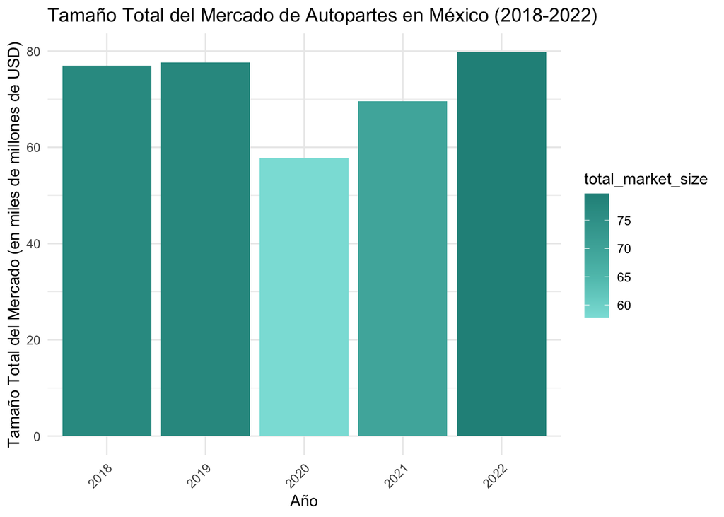

```r
mx_autoparts_market <- na.omit(mx_autoparts_market)

turquoise_palette <- c("#8ae0db", "#5dc1b9", "#42a8a1", "#239089")

# Crear la gráfica de barras con escala de color personalizada
ggplot(mx_autoparts_market, aes(x = factor(year), y = total_market_size, fill = total_market_size)) +
  geom_bar(stat = "identity") +
  scale_fill_gradientn(colors = turquoise_palette) +
  labs(x = "Año", y = "Tamaño Total del Mercado (en miles de millones de USD)",
       title = "Tamaño Total del Mercado de Autopartes en México (2018-2022)") +
  theme_minimal() +
  theme(axis.text.x = element_text(angle = 45, hjust = 1))
```

**1. Impacto de la Pandemia en 2020:** - La marcada caída en 2020 puede correlacionarse con la pandemia de COVID-19, que afectó globalmente la producción y venta de automóviles. Para una empresa como FORM, especializada en empaques para autopartes, esto podría haber representado un reto significativo, posiblemente llevando a una reducción en la demanda de sus productos de empaquetado.

**2. Recuperación Post-Pandemia:** - El rebote en 2021 sugiere una recuperación post-pandemia que habría podido generar un aumento en la demanda de vehículos y, consecuentemente, de autopartes. Esto puede haber sido una oportunidad para FORM de expandir o diversificar su línea de productos de empaque, aprovechando la reactivación del mercado.

**3. Innovación como Factor de Crecimiento:** - La innovación de productos de empaque que permiten ahorros significativos en espacio y costos de logística por parte de FORM podría haber sido un factor determinante en su potencial de crecimiento durante el periodo de recuperación económica, especialmente considerando la tendencia creciente hacia la eficiencia y sostenibilidad en la industria automotriz.

**4. Potencial para el Futuro:** - Dada la tendencia de recuperación del mercado en 2022, empresas como FORM están bien posicionadas para capitalizar el crecimiento continuo de la industria automotriz. La adaptación a las nuevas normativas ambientales y la mejora en la eficiencia de la cadena de suministro serán claves para su éxito futuro.

#### Industria del cartón

```r
carton_exp = read.csv("/Users/daviddrums180/Tec/Case_Study_Form/databases/industry_carton/temporary/Exporters of Carton boxes cases of corrugated paper or board 2020-2021.csv")
carton_imp = read.csv("/Users/daviddrums180/Tec/Case_Study_Form/databases/industry_carton/temporary/Importers of Cartons boxes cases of corrugated paper or board 2020-2021.csv")
electric_2016=read.csv("/Users/daviddrums180/Tec/Case_Study_Form/databases/industry_autos_usa/temporary/mx_venta_vehiculos_hibridos_electricos_2016.csv")
electric_2017=read.csv("/Users/daviddrums180/Tec/Case_Study_Form/databases/industry_autos_usa/temporary/mx_venta_vehiculos_hibridos_electricos_2017.csv")
electric_2018=read.csv("/Users/daviddrums180/Tec/Case_Study_Form/databases/industry_autos_usa/temporary/mx_venta_vehiculos_hibridos_electricos_2018.csv")
electric_2019=read.csv("/Users/daviddrums180/Tec/Case_Study_Form/databases/industry_autos_usa/temporary/mx_venta_vehiculos_hibridos_electricos_2019.csv")
electric_2020=read.csv("/Users/daviddrums180/Tec/Case_Study_Form/databases/industry_autos_usa/temporary/mx_venta_vehiculos_hibiridos_electricos_2020.csv")
electric_2021=read.csv("/Users/daviddrums180/Tec/Case_Study_Form/databases/industry_autos_usa/temporary/mx_venta_vehiculos_hibridos_electricos_2021.csv")
electric_2022=read.csv("/Users/daviddrums180/Tec/Case_Study_Form/databases/industry_autos_usa/temporary/mx_venta_vehiculos_hibridos_electricos_2022.csv")
electric_2023=read.csv("/Users/daviddrums180/Tec/Case_Study_Form/databases/industry_autos_usa/temporary/mx_venta_vehiculos_hibridos_electricos_2023.csv")
```

*Exportaciones*

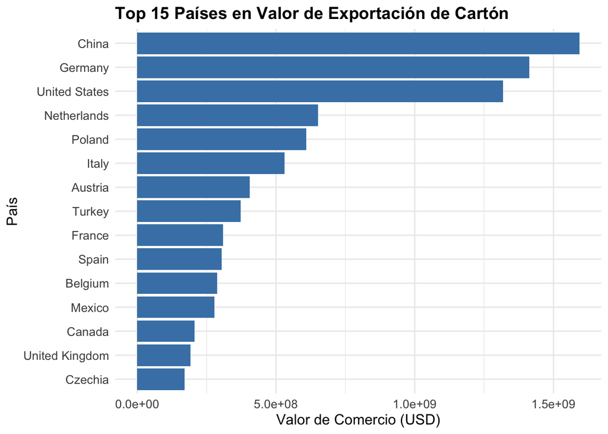

```r
# Filtrar los 15 países con mayores valores de comercio de exportación
top_countries <- carton_exp %>%
  group_by(Country) %>%
  summarize(TotalTradeValue = sum(Trade.Value)) %>%
  top_n(15, TotalTradeValue) %>%
  arrange(desc(TotalTradeValue))

# Unir los datos filtrados con el data.frame original para obtener los datos completos de esos países
top_countries_data <- carton_exp %>%
  filter(Country %in% top_countries$Country)

# Crear el gráfico
ggplot(top_countries_data, aes(x = reorder(Country, Trade.Value), y = Trade.Value)) +
  geom_col(fill = "steelblue") +
  coord_flip() + # Hacer que el gráfico sea horizontal para mejor lectura
  labs(title = "Top 15 Países en Valor de Exportación de Cartón",
       x = "País",
       y = "Valor de Comercio (USD)") +
  theme_minimal() +
  theme(plot.title = element_text(size = 14, face = "bold"),
        axis.title.x = element_text(size = 12),
        axis.title.y = element_text(size = 12),
        axis.text.x = element_text(size = 10),
        axis.text.y = element_text(size = 10))
```

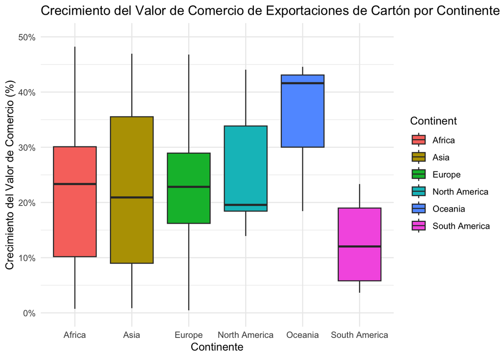

```r
ggplot(carton_exp, aes(x = Continent, y = Trade.Value.Growth * 100, fill = Continent)) +
  geom_boxplot() +
  scale_y_continuous(limits = c(0, 50), breaks = seq(0, 50, 10), labels = paste0(seq(0, 50, 10), "%")) +
  labs(title = "Crecimiento del Valor de Comercio de Exportaciones de Cartón por Continente",
       x = "Continente",
       y = "Crecimiento del Valor de Comercio (%)") +
  theme_minimal()
```

En cuanto al crecimiento de la industria del cartón por continente, podemos ver que Oceanía es el continente con el mayor porcentaje de crecimiento, sin embargo, la mediana del continente norteamericano es de poco menos del 20%, lo que indica que hay una tendencia positiva de esta industria en nuestro continente.

*Importaciones*

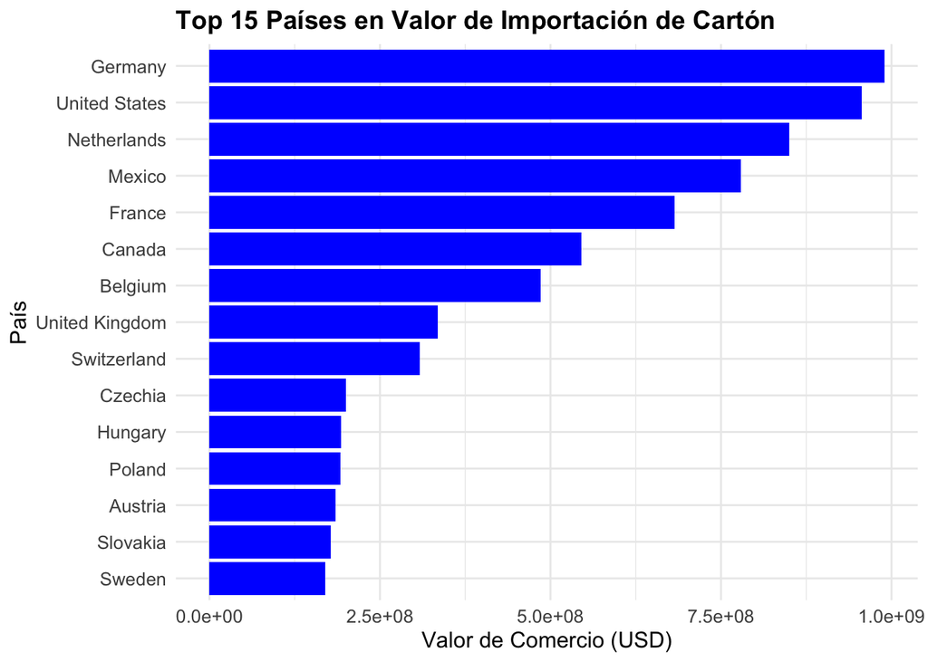

```r
# Filtrar los 15 países con mayores valores de comercio de importación

top_countries_2 <- carton_imp %>%
  group_by(Country) %>%
  summarize(TotalTradeValue = sum(Trade.Value)) %>%
  top_n(15, TotalTradeValue) %>%
  arrange(desc(TotalTradeValue))

# Unir los datos filtrados con el data.frame original para obtener los datos completos de esos países
top_countries_data_2 <- carton_imp %>%
  filter(Country %in% top_countries_2$Country)

# Crear el gráfico
ggplot(top_countries_data_2, aes(x = reorder(Country, Trade.Value), y = Trade.Value)) +
  geom_col(fill = "blue") +
  coord_flip() +
  labs(title = "Top 15 Países en Valor de Importación de Cartón",
       x = "País",
       y = "Valor de Comercio (USD)") +
  theme_minimal() +
  theme(plot.title = element_text(size = 14, face = "bold"),
        axis.title.x = element_text(size = 12),
        axis.title.y = element_text(size = 12),
        axis.text.x = element_text(size = 10),
        axis.text.y = element_text(size = 10))
```

#### Industria de vehículos eléctricos

```r
# Crear una lista de dataframes para iterar
electric_dfs <- list(electric_2016 = electric_2016, electric_2017 = electric_2017,
                     electric_2018 = electric_2018, electric_2019 = electric_2019,
                     electric_2020 = electric_2020, electric_2021 = electric_2021,
                     electric_2022 = electric_2022, electric_2023 = electric_2023)

# Inicializar un vector para almacenar los totales de ventas de vehículos eléctricos por año
total_sales_by_year <- numeric(length(electric_dfs))
names(total_sales_by_year) <- names(electric_dfs)

# Sumar las ventas de vehículos eléctricos por año
for (year in names(electric_dfs)) {
  total_sales_by_year[year] <- sum(electric_dfs[[year]]$VEH_ELECTR, na.rm = TRUE)
}

# Convertir a data.frame
sales_df <- data.frame(Year = names(total_sales_by_year),
                       ElectricVehicleSales = total_sales_by_year)

# Ver el resultado
print(sales_df)
```

```
##                        Year ElectricVehicleSales
## electric_2016 electric_2016                  254
## electric_2017 electric_2017                  237
## electric_2018 electric_2018                  201
## electric_2019 electric_2019                  305
## electric_2020 electric_2020                  449
## electric_2021 electric_2021                 1140
## electric_2022 electric_2022                 5631
## electric_2023 electric_2023                 4130
```

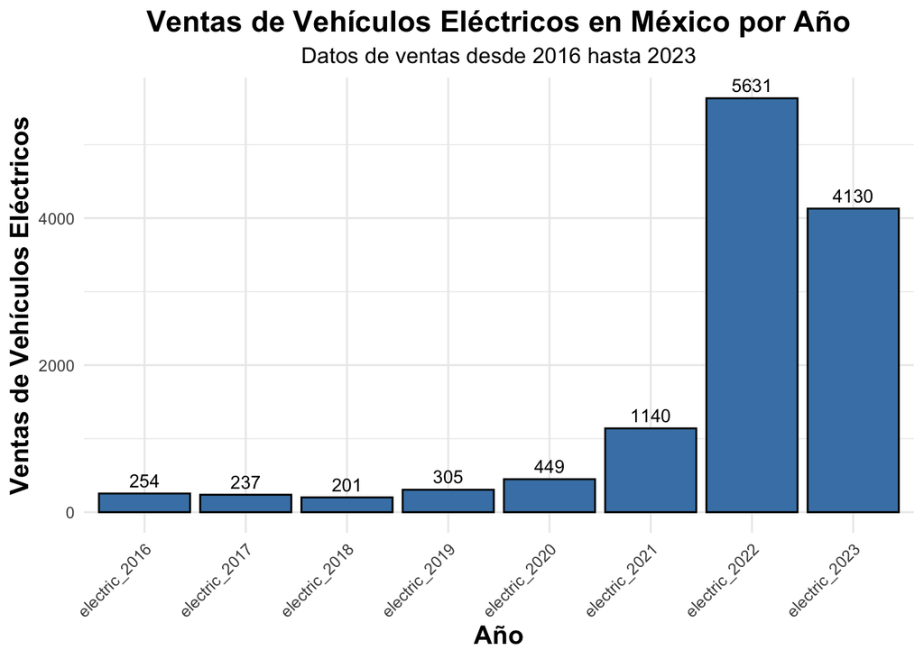

```r
# Asumiendo que sales_df ya está creado y contiene las columnas 'Year' y 'ElectricVehicleSales'
ggplot(sales_df, aes(x = Year, y = ElectricVehicleSales)) +
  geom_col(fill = "steelblue", color = "black") + # Usamos barras con colores personalizados
  geom_text(aes(label = ElectricVehicleSales), vjust = -0.5, size = 3.5) + # Añadir etiquetas de texto sobre las barras
  labs(title = "Ventas de Vehículos Eléctricos en México por Año",
       subtitle = "Datos de ventas desde 2016 hasta 2023",
       x = "Año",
       y = "Ventas de Vehículos Eléctricos") +
  theme_minimal() + # Tema minimalista
  theme(plot.title = element_text(hjust = 0.5, size = 16, face = "bold"), # Centrar y dar formato al título
        plot.subtitle = element_text(hjust = 0.5, size = 12), # Centrar el subtítulo
        axis.title.x = element_text(size = 14, face = "bold"), # Formato para el título del eje X
        axis.title.y = element_text(size = 14, face = "bold"), # Formato para el título del eje Y
        axis.text.x = element_text(angle = 45, hjust = 1)) # Rotar las etiquetas del eje X para mejorar la legibilidad
```

Como se puede apreciar en la gráfica, las ventas en México de los vehículos eléctricos tienen una clara tendencia positiva desde hace varios años, esto refleja la oportunidad y la necesidad de que empresas como FORM adapten su oferta de soluciones a las nuevas autopartes que requieren este nuevo tipo de vehículos.

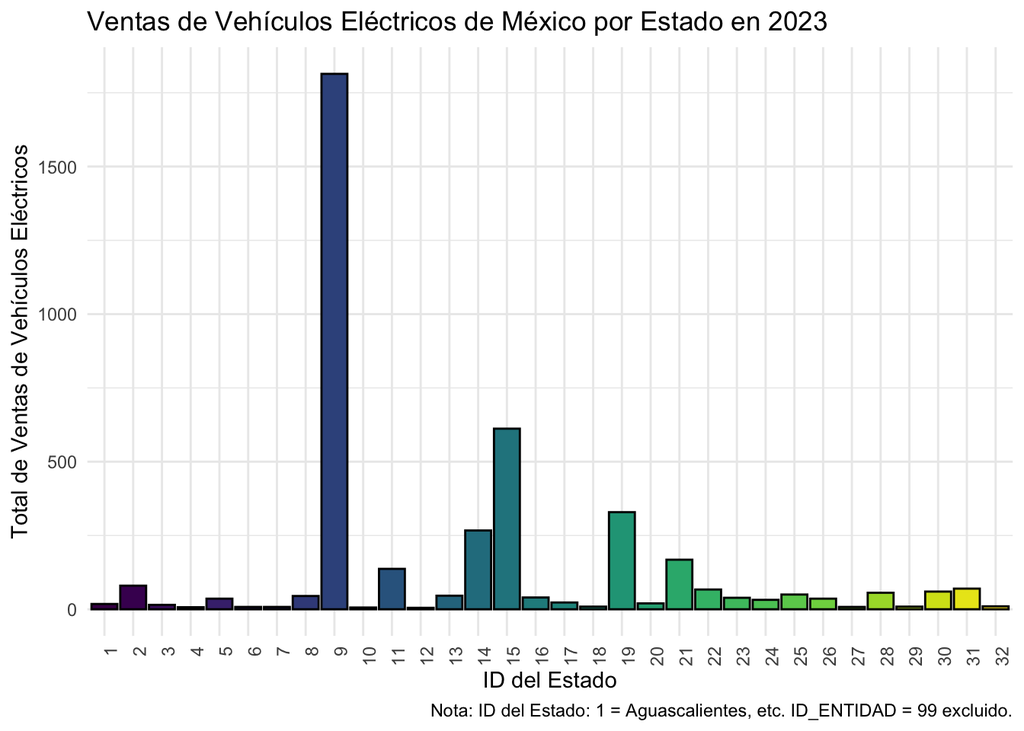

```r
#Se detectó un error en ID_ENTIDAD, existiendo el ID=99.
# Filtrar para eliminar ID_ENTIDAD = 99
datos_filtrados <- electric_2023 %>%
  filter(ID_ENTIDAD != 99)



# Agrupar datos por ID_ENTIDAD y sumar las ventas de vehículos eléctricos
ventas_por_estado <- datos_filtrados %>%
  group_by(ID_ENTIDAD) %>%
  summarise(Total_VEH_ELECTR = sum(VEH_ELECTR, na.rm = TRUE))

estados_mexico <- c("Aguascalientes", "Baja California", "Baja California Sur", "Campeche", "Chiapas",
                    "Chihuahua", "Ciudad de México", "Coahuila", "Colima", "Durango", "Guanajuato",
                    "Guerrero", "Hidalgo", "Jalisco", "México", "Michoacán", "Morelos", "Nayarit",
                    "Nuevo León", "Oaxaca", "Puebla", "Querétaro", "Quintana Roo", "San Luis Potosí",
                    "Sinaloa", "Sonora", "Tabasco", "Tamaulipas", "Tlaxcala", "Veracruz", "Yucatán", "Zacatecas")

datos_filtrados$ID_ENTIDAD <- as.numeric(datos_filtrados$ID_ENTIDAD)

# Agregar una nueva columna con los nombres de los estados
datos_filtrados <- datos_filtrados %>%
  mutate(Estado = estados_mexico[ID_ENTIDAD])

# Crear la gráfica
ggplot(ventas_por_estado, aes(x = factor(ID_ENTIDAD), y = Total_VEH_ELECTR, fill = factor(ID_ENTIDAD))) +
  geom_bar(stat = "identity", color = "black", show.legend = FALSE) +
  scale_fill_viridis_d() +
  labs(title = "Ventas de Vehículos Eléctricos de México por Estado en 2023",
       x = "ID del Estado",
       y = "Total de Ventas de Vehículos Eléctricos",
       caption = "Nota: ID del Estado: 1 = Aguascalientes, etc. ID_ENTIDAD = 99 excluido.") +
  theme_minimal() +
  theme(axis.text.x = element_text(angle = 90, hjust = 1))
```

### FODA Cruzado

Apartir de los antecedentes de la empresa y el contexto de la industrias de México y E.U.A. elaborar FODA cruzado que identifique y describa 2-3 estrategias a seguir por parte de la empresa en el corto plazo.

#### Fortalezas:

1. Expertos en desarrollar soluciones de empaque sostenibles e innovadoras con un enfoque en la industria automotriz, optimizando el espacio de almacenamiento, así como los costos logísticos lo que indica un profundo entendimiento de las necesidades del sector automotriz.
2. Asociaciones con marcas de alto prestigio, la empresa de Form ha establecido relaciones comerciales como lo es Tesla, lo que nos indica la alta calidad y confiabilidad de sus soluciones de empaque.
3. Compromiso con la sostenibilidad, la empresa integra prácticas sostenibles en su modelo de negocio, desde reducciones de uso de materiales hasta la optimización de logística, que se alinean con la demanda actual de la industria hacia prácticas más ecológicas.

#### Oportunidades:

1. Crecimiento del mercado en la industria con empaques sostenibles. La conciencia ambiental y regulaciones de la sostenibilidad, presentan una gran oportunidad para la empresa en liderar el desarrollo y oferta de soluciones en los empaques sostenibles.
2. Demanda creciente de empaques personalizados para los clientes debido a cambios en los consumidores. La tendencia hacia servicios y productos personalizados para sus clientes, requiere una mayor demanda de empaques que se ajusten a las necesidades individuales de sus clientes.
3. Oportunidad de expansión en industrias fuera de la industria automotriz que requieren de soluciones innovadoras de empaque. Otras industrias también requieren de soluciones de empaque innovadoras lo que presenta una oportunidad para la empresa de expandir su mercado a otros sectores.

#### Debilidades:

1. Actualmente se encuentran en potencial dependencia de la industria automotriz. Esto podría representar un alto riesgo si el sector llegará a enfrentar disminuciones en la demanda o desafíos económicos.
2. Necesidad en estar actualizados continuamente frente a tecnologías en desarrollo de empaque. Mantenerse en constante innovación requiere inversión en investigaciones y desarrollo, lo que puede ser un reto en recursos y capital.
3. Limitaciones en la diversificación de productos. La especialización que tienen sobre los empaques de autopartes podría limitar la capacidad de la empresa para capitalizar y explorar oportunidades en otros mercados y productos.

#### Amenazas:

1. Constante cambio en las regulaciones ambientales que pueden afectar los materiales para realizar los empaques. Puede haber un gran impacto al usar ciertos procesos y materiales que requieren de adaptaciones costosas.
2. Gran competencia creciente en el sector de empaques sostenibles. El crecimiento de la industria y su demanda de soluciones de empaques sostenibles atrae a nuevos competidores, esto incrementa la presión para la empresa por diferenciarse y continuar innovando.
3. Volatilidad en los costos de materiales debido a fluctuaciones del mercado. Esto puede afectar los márgenes de beneficio y la competitividad de precios de las soluciones de FORM.

#### Estrategias:

Estrategias FODA Cruzado para FORM

##### Fortalezas-Oportunidades (FO)

- **Sostenibilidad e Innovación:** Utilizar la experiencia y el compromiso de la empresa con la sostenibilidad para poder liderar en la industria y en el mercado con empaques renovables y ecológicos para seguir creciendo ante la demanda.
- **Expansión en Servicios Personalizados:** Desarrollar soluciones personalizadas a los clientes y mejorar su relación con marcas de prestigio.

##### Debilidades-Oportunidades (DO)

- **Mitigar dependencias en el mercado:** Ampliar el mercado hacia nuevas industrias, para reducir la dependencia del sector automotriz, creciendo a nuevos mercados con demanda creciente a soluciones innovadoras.
- **Colaboraciones con Innovación:** Realizar colaboraciones estratégicas para dividir el costo de riesgo de innovación y desarrollo, dándole a la empresa un gran alcance para ser el líder en la industria.

##### Fortalezas-Amenazas (FA)

- **Liderazgo ante Cambios regulatorios:** Emplear compromiso con la innovación y sostenibilidad para que la empresa se adapte ante los cambios en regulaciones ecológicas, posicionando a FORM como un referente en cumplimiento y adaptabilidad.
- **Valor agregado frente a la Competencia:** Fortalecer a la empresa a través de su confiabilidad con sus clientes, aprovechando su calidad para destacarse en el mercado competitivo, así mismo aprovechando sus colaboraciones con marcas de alto prestigio.

##### Debilidades-Amenazas (DA)

- **Cobertura de riesgo en Costos:** Realizar estrategias para tomar medidas de prevención para protegerse contra la volatilidad de los precios de los materiales, como lo es la diversificación de los proveedores y los contratos de la empresa a largo plazo.
- **Programas de Lealtad con Clientes:** Implementar programas de colaboración y lealtad con los clientes actuales, para poder mejorar la relación a largo plazo y mitigar el impacto de la competencia y las fluctuaciones del mercado.

### PESTLE

Con base en el análisis de las industrias de México y E.U.A. identificar variables / factores relevantes para la elaboración de PESTLE y describir 2-3 estrategias a seguir por parte de la empresa en el corto plazo.

#### Políticos.

EE.UU. advierte terminar tratado de comercio con México por fábricas de carros chinos. Las futuras elecciones pueden ser un factor muy importante en la industria automotriz, ya que según BBC News, Trump se muestra de manera muy hostil ante los fabricantes de automóviles. Por lo que, puede que imponga alguna ley que afecte negativamente la industria. El Tratado entre México, Estados Unidos y Canadá (T-MEC) establece reglas para el comercio entre los tres países, incluyendo la industria automotriz. El T-MEC ha sido positivo para la industria automotriz mexicana, ya que ha aumentado la producción y las exportaciones. El gobierno mexicano ha implementado una serie de políticas para promover la industria automotriz, como la creación de un fondo de apoyo a la industria y la reducción de impuestos a la importación de autopartes.

#### Económicos.

Sector automotriz, con la mayor demanda de espacios industriales por Nearshoring. Industria automotriz aumenta 7.8% la producción en febrero. México recibirá 2 mil 300 mdd de inversión extranjera en autopartes en 2024: INA. El nearshoring puede reducir los costos de producción al aprovechar la mano de obra más barata en países cercanos. Esto puede mejorar la competitividad de FORM en el mercado. La tasa de interés en Estados Unidos ha aumentado en los últimos años. Esto ha encarecido el crédito para los consumidores, lo que podría afectar la demanda de vehículos.

#### Sociales.

La clase media en México está creciendo. Esto ha aumentado la demanda de vehículos, ya que las personas de la clase media tienen más dinero para gastar. Las preocupaciones ambientales están aumentando en Estados Unidos. Esto podría afectar la demanda de vehículos, ya que los consumidores podrían optar por comprar vehículos más eficientes en combustible o vehículos eléctricos.

#### Tecnológicos.

Se busca que en México solo se vendan autos eléctricos. Protagonistas de la industria automotriz en México han unido fuerzas para crear la Electro Movilidad Asociación (EMA), alianza que nace con el objetivo de alcanzar el 100 por ciento de ventas de vehículos eléctricos para el año 2035.

#### Legales.

Exportación de autos made in México crece 22.6% en febrero y acelera a máximo histórico. Stellantis anuncia importante plan de inversiones para América Latina. Las regulaciones de seguridad para los vehículos están aumentando en todo el mundo. Esto está obligando a las empresas automotrices a invertir en nuevas tecnologías de seguridad.

#### Ecológicos.

La Industria Nacional de Autopartes aseguró que la producción de baterías para autos eléctricos en Norteamérica es fundamental para cumplir con las reglas de origen del T-MEC. El cambio climático es una preocupación importante para la industria automotriz. Las empresas automotrices están desarrollando vehículos más eficientes en combustible y vehículos eléctricos para reducir su impacto ambiental.

## REFERENCIAS

Mendoza, C. (2024, March 6). La Industria Automotriz en pro de la electromovilidad. La Jornada. https://www.jornada.com.mx/noticia/2024/03/05/autos/la-industria-se-une-en-pro-de-la-electromovilidad-9327 Sáez, C. (2024, March 6). Industria Automotriz Aumenta 7.8% La Producción en Febrero. MVS Noticias. https://mvsnoticias.com/economia/2024/3/6/industria-automotriz-aumenta-78-la-produccion-en-febrero-629503.html El nearshoring Cuadriplicó La Demanda de Espacios Industriales … (n.d.). https://www.eleconomista.com.mx/econohabitat/El-nearshoring-cuadriplico-la-demanda-de-espacios-industriales-en-el-pais-20230315-0126.html México Batió Récord de exportación de autos ligeros para un febrero. (n.d.-b). https://www.eleconomista.com.mx/empresas/Exportacion-de-autos-made-in-Mexico-crece-22.6-en-febrero-y-acelera-a-maximo-historico-20240306-0058.html Stellantis, Noticias Sobre Stellantis | El Economista. (n.d.-c). https://www.eleconomista.com.mx/tags/Stellantis Nexteer coloca La primera piedra de mxtc para promover la innovación automotriz en querétaro. Cluster Indutrial. (n.d.). https://www.clusterindustrial.com.mx/noticia/7386/nexteer-coloca-la-primera-piedra-de-mxtc-para-promover-la-innovacion-automotriz-en-queretaro Navarrete, F. (2024, March 5). Venta de Autos “Acelera” 14.8% en el primer bimestre del 2024. El Financiero. https://www.elfinanciero.com.mx/empresas/2024/03/05/venta-de-autos-acelera-148-en-el-primer-bimestre-del-2024/ Cecilia Conde / Diario de Querétaro. (2024, March 6). Dispara crecimiento el sector autopartes en querétaro. Diario de Querétaro | Noticias Locales, Policiacas, de México, Querétaro y el Mundo. https://www.diariodequeretaro.com.mx/finanzas/dispara-crecimiento-el-sector-autopartes-en-queretaro-11550455.html Bohórquez, P. R. (2024, March 4). EE.UU. Advierte terminar tratado de comercio con México por fábricas de carros chinos. El Carro Colombiano. https://www.elcarrocolombiano.com/industria/ee-uu-advierte-terminar-tratado-de-comercio-con-mexico-por-fabricas-de-carros-chinos/ Juárez, P. (2024, March 7). Industria de autopartes Alcanza Récord de Producción en 2023. Revista TyT. https://www.tyt.com.mx/nota/industria-de-autopartes-alcanza-record-de-produccion-en-2023 Packing, F.-. R. F. O. (2021, 23 agosto). The form way -. Form. Recuperado 7 de marzo de 2024, de https://form.com.mx/the-form-way/ Isidore, C. (2018, 29 noviembre). La amenaza existencial que enfrenta la industria automotriz. Expansión. Recuperado 7 de marzo de 2024, de https://expansion.mx/empresas/2018/11/29/la-amenaza-existencial-que-enfrenta-la-industria-automotriz FORM: transformando el mundo del empaque para el sector automotriz. (2022, 27 diciembre). Cluster Indutrial. Recuperado 7 de marzo de 2024, de https://www.clusterindustrial.com.mx/noticia/5640/form-transformando-el-mundo-del-empaque-para-el-sector-automotriz Industrial C., (2022), FORM: transformando el mundo del empaque para el sector automotriz, Cluster Industrial. https://www.clusterindustrial.com.mx/noticia/5640/form-transformando-el-mundo-del-empaque-para-el-sector-automotriz